# Prediction Assignment Writeup

Jose A. Ruiperez Valiente

30 de enero de 2016

# Preliminar work

## Background of the project

Using devices such as Jawbone Up, Nike FuelBand, and Fitbit it is now possible to collect a large amount of data about personal activity relatively inexpensively. These type of devices are part of the quantified self movement – a group of enthusiasts who take measurements about themselves regularly to improve their health, to find patterns in their behavior, or because they are tech geeks. One thing that people regularly do is quantify how much of a particular activity they do, but they rarely quantify how well they do it. In this project, your goal will be to use data from accelerometers on the belt, forearm, arm, and dumbell of 6 participants. They were asked to perform barbell lifts correctly and incorrectly in 5 different ways. More information is available from the website here: http://groupware.les.inf.puc-rio.br/har (see the section on the Weight Lifting Exercise Dataset).

## Data

The training data for this project are available here: https://d396qusza40orc.cloudfront.net/predmachlearn/pml-training.csv

The test data are available here: https://d396qusza40orc.cloudfront.net/predmachlearn/pml-testing.csv

The data for this project come from this source: http://groupware.les.inf.puc-rio.br/har. If you use the document you create for this class for any purpose please cite them as they have been very generous in allowing their data to be used for this kind of assignment.

## Required submissions

The goal of your project is to predict the manner in which they did the exercise. This is the “classe” variable in the training set. You may use any of the other variables to predict with. You should create a report describing how you built your model, how you used cross validation, what you think the expected out of sample error is, and why you made the choices you did. You will also use your prediction model to predict 20 different test cases.

# Analysis

## Preparing the work environment

First we load the libraries, echo false to supress messages

```r
library(RCurl)
library(caret)
library(randomForest)
```

```r
library(rpart)
library(rpart.plot)
library(reshape2)
```

Download data

```r
download.file("https://d396qusza40orc.cloudfront.net/predmachlearn/pml-training.csv",destfile="pml-training.csv",method="curl")
training <- read.csv("pml-training.csv", na.strings=c("NA","#DIV/0!", ""))
download.file("https://d396qusza40orc.cloudfront.net/predmachlearn/pml-testing.csv",destfile="pml-testing.csv",method="curl")
testing <- read.csv("pml-testing.csv", na.strings=c("NA","#DIV/0!", ""))
```

## Exploratory analysis and data cleaning

Exploration of data.

```r
summary(training)
str(training)
```

What we learn after exploring data are three main things: 1. Dataset contains many variables which are mostly NA’s 2. Dataset contains experiment-related variables such as id or timestamp that are not interesting for prediction purposes 3. Dataset contains variables with near to zero variance, which may not be very informative taking into account that the datasets contains a wide amount of variables

Thus I choose to remove all the previously mention variables

```r
# Remove the first 7 variables which contain information related to the experiment
training <- training[,-c(1:7)]

# Removing Vars NA values
variablesWithNA <- sapply(training, function (x) any(is.na(x) | x == ""))
training <- training[, names(variablesWithNA[!variablesWithNA])]

# Removing Near Zero Var (NZV)
near.zero.vars <- nearZeroVar(training, saveMetrics=TRUE)
training <- training[, !near.zero.vars$nzv]

# Selected variables
names(training)
```

```
##  [1] "roll_belt"            "pitch_belt"           "yaw_belt"
##  [4] "total_accel_belt"     "gyros_belt_x"         "gyros_belt_y"
##  [7] "gyros_belt_z"         "accel_belt_x"         "accel_belt_y"
## [10] "accel_belt_z"         "magnet_belt_x"        "magnet_belt_y"
## [13] "magnet_belt_z"        "roll_arm"             "pitch_arm"
## [16] "yaw_arm"              "total_accel_arm"      "gyros_arm_x"
## [19] "gyros_arm_y"          "gyros_arm_z"          "accel_arm_x"
## [22] "accel_arm_y"          "accel_arm_z"          "magnet_arm_x"
## [25] "magnet_arm_y"         "magnet_arm_z"         "roll_dumbbell"
## [28] "pitch_dumbbell"       "yaw_dumbbell"         "total_accel_dumbbell"
## [31] "gyros_dumbbell_x"     "gyros_dumbbell_y"     "gyros_dumbbell_z"
## [34] "accel_dumbbell_x"     "accel_dumbbell_y"     "accel_dumbbell_z"
## [37] "magnet_dumbbell_x"    "magnet_dumbbell_y"    "magnet_dumbbell_z"
## [40] "roll_forearm"         "pitch_forearm"        "yaw_forearm"
## [43] "total_accel_forearm"  "gyros_forearm_x"      "gyros_forearm_y"
## [46] "gyros_forearm_z"      "accel_forearm_x"      "accel_forearm_y"
## [49] "accel_forearm_z"      "magnet_forearm_x"     "magnet_forearm_y"
## [52] "magnet_forearm_z"     "classe"
```

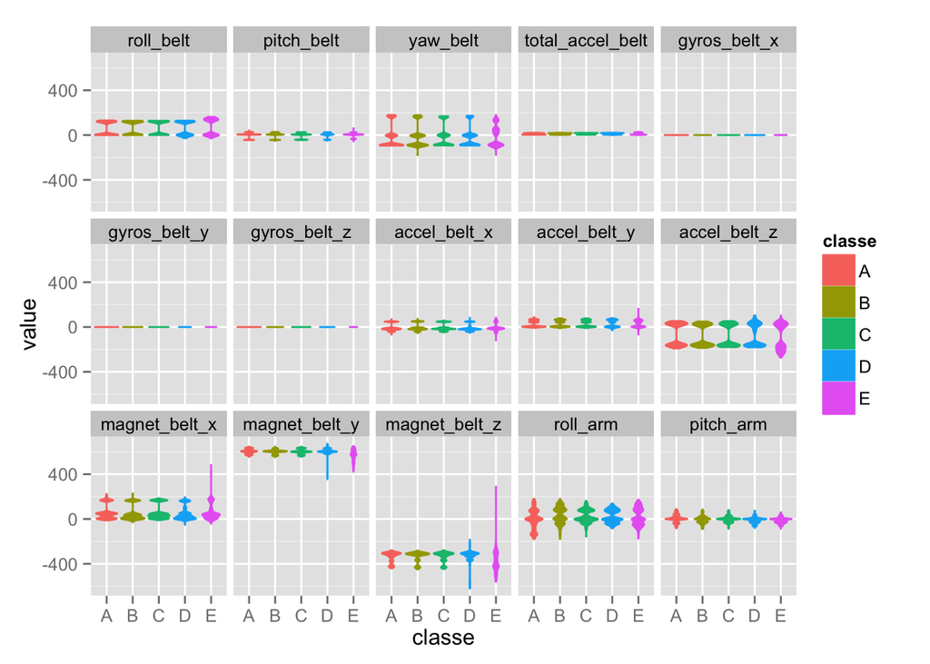

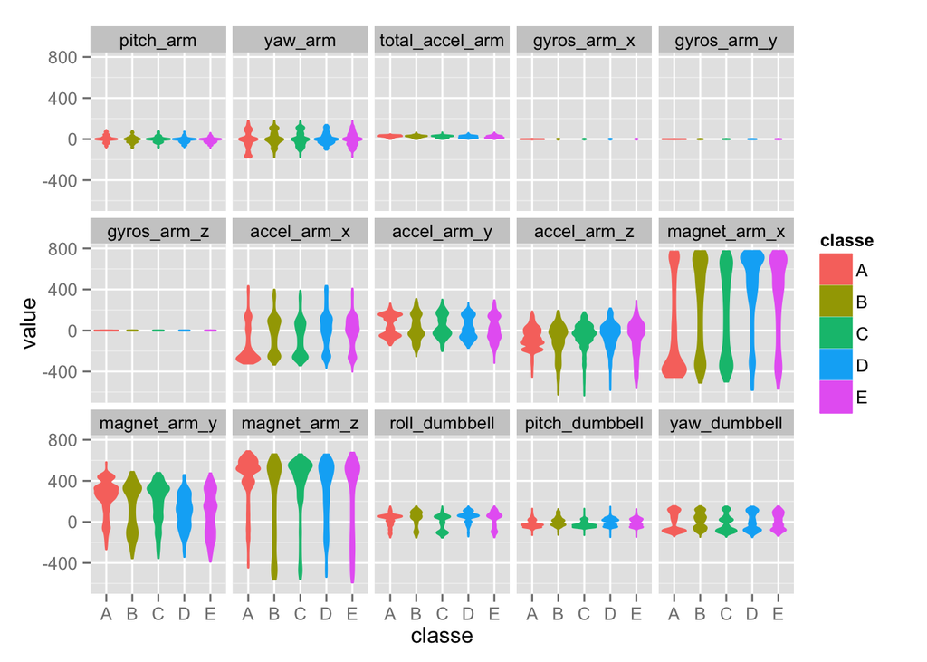

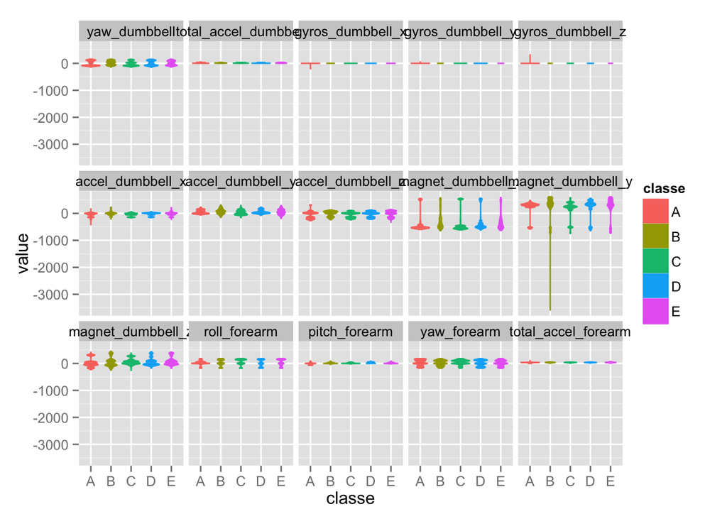

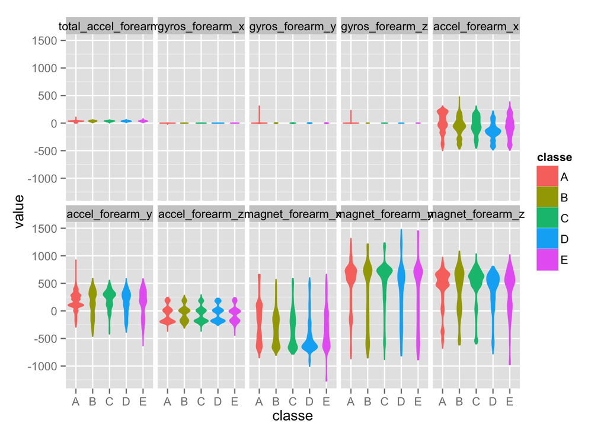

```r
# Visualizing boxplot of the predictors per classe type
variables <- names(training[,!names(training) %in% "classe"])
v_per_plot = 14

for(i in 1:ceiling(length(names(training))/v_per_plot))  # for each row
{
min <- 1 + (i-1)*v_per_plot
max <- 1 + i*v_per_plot
if (max > length(variables))
{
  max <- length(variables)
}
var_to_plot <- c(variables[min:max], "classe")

p <- ggplot() + geom_violin(aes(y = value, x = classe, color = classe, fill=classe), data = melt(training[, var_to_plot], id.vars = "classe")) + facet_wrap(~ variable, ncol = 5)
print(p)
}
```

## Model

```r
set.seed(591852)
training$classe <- factor(training$classe)
# Create training and validation set with 0.6 probability
inTrain <- createDataPartition(training$classe, p=0.6)
train_set <- training[inTrain[[1]],]
validate_set <- training[-inTrain[[1]],]
```

```r
library(parallel)
library(doParallel)
cl <- makeCluster(detectCores() - 1)
registerDoParallel(cl)

ctrl <- trainControl(classProbs=TRUE, savePredictions=TRUE, allowParallel=TRUE)
mod_rf <- train(classe ~ ., method="rf", data = train_set)
stopCluster(cl)
```

## Validating the model

```r
# Test on the train set with 100% accuracy
confusionMatrix(predict(mod_rf, train_set), train_set$classe)
```

```
## Confusion Matrix and Statistics
##
##           Reference
## Prediction    A    B    C    D    E
##          A 3348    0    0    0    0
##          B    0 2279    0    0    0
##          C    0    0 2054    0    0
##          D    0    0    0 1930    0
##          E    0    0    0    0 2165
##
## Overall Statistics
##
##                Accuracy : 1
##                  95% CI : (0.9997, 1)
##     No Information Rate : 0.2843
##     P-Value [Acc > NIR] : < 2.2e-16
##
##                   Kappa : 1
##  Mcnemar's Test P-Value : NA
##
## Statistics by Class:
##
##                      Class: A Class: B Class: C Class: D Class: E
## Sensitivity            1.0000   1.0000   1.0000   1.0000   1.0000
## Specificity            1.0000   1.0000   1.0000   1.0000   1.0000
## Pos Pred Value         1.0000   1.0000   1.0000   1.0000   1.0000
## Neg Pred Value         1.0000   1.0000   1.0000   1.0000   1.0000
## Prevalence             0.2843   0.1935   0.1744   0.1639   0.1838
## Detection Rate         0.2843   0.1935   0.1744   0.1639   0.1838
## Detection Prevalence   0.2843   0.1935   0.1744   0.1639   0.1838
## Balanced Accuracy      1.0000   1.0000   1.0000   1.0000   1.0000
```

```r
# Test on the validation set with 99.25% accuracy
confusionMatrix(predict(mod_rf, validate_set), validate_set$classe)
```

```
## Confusion Matrix and Statistics
##
##           Reference
## Prediction    A    B    C    D    E
##          A 2231    8    0    0    0
##          B    1 1497    6    0    0
##          C    0   11 1357   18    3
##          D    0    0    5 1266    4
##          E    0    2    0    2 1435
##
## Overall Statistics
##
##                Accuracy : 0.9924
##                  95% CI : (0.9902, 0.9942)
##     No Information Rate : 0.2845
##     P-Value [Acc > NIR] : < 2.2e-16
##
##                   Kappa : 0.9903
##  Mcnemar's Test P-Value : NA
##
## Statistics by Class:
##
##                      Class: A Class: B Class: C Class: D Class: E
## Sensitivity            0.9996   0.9862   0.9920   0.9844   0.9951
## Specificity            0.9986   0.9989   0.9951   0.9986   0.9994
## Pos Pred Value         0.9964   0.9953   0.9770   0.9929   0.9972
## Neg Pred Value         0.9998   0.9967   0.9983   0.9970   0.9989
## Prevalence             0.2845   0.1935   0.1744   0.1639   0.1838
## Detection Rate         0.2843   0.1908   0.1730   0.1614   0.1829
## Detection Prevalence   0.2854   0.1917   0.1770   0.1625   0.1834
## Balanced Accuracy      0.9991   0.9925   0.9935   0.9915   0.9973
```

## Prediction of testing set and final model

```r
test_set <- testing[, names(testing) %in% names(training)]
# Prediction of the testing dataset
data.frame(testing[,1:6], classe_predicted = predict(mod_rf, test_set))
```

```
##     X user_name raw_timestamp_part_1 raw_timestamp_part_2   cvtd_timestamp
## 1   1     pedro           1323095002               868349 05/12/2011 14:23
## 2   2    jeremy           1322673067               778725 30/11/2011 17:11
## 3   3    jeremy           1322673075               342967 30/11/2011 17:11
## 4   4    adelmo           1322832789               560311 02/12/2011 13:33
## 5   5    eurico           1322489635               814776 28/11/2011 14:13
## 6   6    jeremy           1322673149               510661 30/11/2011 17:12
## 7   7    jeremy           1322673128               766645 30/11/2011 17:12
## 8   8    jeremy           1322673076                54671 30/11/2011 17:11
## 9   9  carlitos           1323084240               916313 05/12/2011 11:24
## 10 10   charles           1322837822               384285 02/12/2011 14:57
## 11 11  carlitos           1323084277                36553 05/12/2011 11:24
## 12 12    jeremy           1322673101               442731 30/11/2011 17:11
## 13 13    eurico           1322489661               298656 28/11/2011 14:14
## 14 14    jeremy           1322673043               178652 30/11/2011 17:10
```

[output cut: 27 more lines]

```r
# Importance of the variables
varImp(mod_rf)
```

```
## rf variable importance
##
##   only 20 most important variables shown (out of 52)
##
##                      Overall
## roll_belt             100.00
## pitch_forearm          63.32
## yaw_belt               55.84
## magnet_dumbbell_z      44.89
## pitch_belt             44.53
## magnet_dumbbell_y      43.47
## roll_forearm           41.02
## accel_dumbbell_y       21.05
## roll_dumbbell          19.84
## magnet_dumbbell_x      18.11
## accel_forearm_x        16.67
## magnet_belt_z          15.34
## accel_belt_z           14.26
## total_accel_dumbbell   14.17
## accel_dumbbell_z       14.09
## magnet_belt_y          13.28
## magnet_forearm_z       13.02
## gyros_belt_z           12.53
## yaw_arm                10.79
## magnet_belt_x          10.08
```

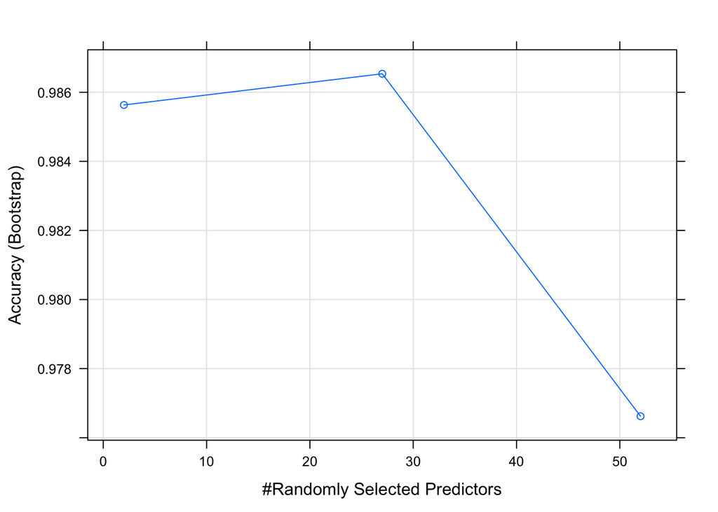

```r
# Log plot of the model
plot(mod_rf, log="y")
```